None

# МАТЕРИАЛЫ

Презентация: https://disk.yandex.ru/i/SrpX4MziKtLYCA

# АНАЛИЗ ДАННЫХ БАНКА "МЕТАНПРОМБАНК" ДЛЯ СЕГМЕНТАЦИИ КЛИЕНТОВ И СНИЖЕНИЯ УРОВНЯ ОТТОКА КЛИЕНТОВ

## ВВЕДЕНИЕ

### Структура работы

**1. Введение** - общая информация о работе: заказчик, предварительное описание результата работы, описание структуры работы, формулировка целей и задач, описание набора данных.

**2. Подготовка данных** - добавление нужных библиотек, предварительная обработка данных, в которую входит обработка пропусков и дубликатов с кратким анализом их происхождения, добавление столбцов, приведение данных к нужным форматам, кодирование и т.д.

**3. Исследовательский анализ данных** - общий анализ данных, а именно: сравнение портретов типичных клиентов, распределения, корреляционный анализ; исследование оттока в разрезе значений признаков (диапазонов признаков).

**4. Проверка статистических гипотез** - формулирование дополнительных гипотез, выбор и обоснование статистического теста, проверка статистических гипотез и промежуточные выводы; определение признаков для сегментации и т.д.

**5. Специальный анализ данных** - решение задач работы: сегментация на основе выделенных показателей.

**6. Заключение** - финальный вывод и рекомендации, презентация.

### Обоснование необходимости работы

Серьезно повысился отток клиентов банка до степени, когда это угрожает существованию банка. Планируется разработка новой линейки продуктов для удержания отточных клиентов и привлечения лояльных клиентов.

Результаты предыдущего исследования не актуальны, так как изменился состав клиентов банка и старые сегменты более не подходят.

### Заказчик работы

Заказчик работы - отдел маркетинга. Информация необходима менеджеру, который занимается маркетинговыми кампаниями и работает в связке с менеджерами продуктов.

### Цель работы

Составить портрет клиента банка "Метанпромбанк": сегменты по продуктам, которые подходят клиентам, либо сегменты по количеству используемых продуктов, и по признакам отточности.

### Задачи работы

В рамках данного проекта будет выполнена задача по сегментации клиентов банка "Метанпромбанк" по продуктам и отточности, и проверен ряд гипотез, которые будут сформулированы в разделе 3.

### Описание данных

**userid**: идентификатор пользователя (*примечание: монотонно возрастает со временем*)

**score**: баллы кредитного скоринг

**city**: город

**gender**: пол

**age**: возраст

**equity**: количество баллов собственности

**balance**: баланс на счете

**products**: количество продуктов, которое используется клиентом

**credit_card**: есть ли кредитная карта

**last_activity**: активный клиент

**est_salary**: оценочный доход клиента (*примечание: среднемесячный*)

**churn**: признак оттока (*примечание: клиент уже ушел либо стопроцентно уйдет в ближайшее время*)

## ПОДГОТОВКА ДАННЫХ

к содержанию

### Импорт библиотек

```python
import pandas as pd
import matplotlib.pyplot as plt
import seaborn as sns
import numpy as np
from scipy import stats as st
from statsmodels.stats.proportion import proportions_ztest
from matplotlib import colors
from matplotlib.ticker import AutoLocator
```

### Полезные функции

```python
def addlabels(x,y,z,horiz=False,rot=75):
    if horiz==True:
        for i in range(len(x)):
            plt.text(y[i],i-0.15,z[i],rotation=rot)
    else:
        for i in range(len(x)):
            plt.text(i-0.15,y[i],z[i],rotation=rot)
```

```python
def classify_data(df,excl_cat=''):
    cat_dict ={}
    for col in df.columns:
        if col!=excl_cat:
            if df[col].isin([0,1]).all() or df[col].dtype=='bool':
                cat_dict[col]='cat'
            elif df[col].dtype=='object':
                cat_dict[col]='obj'
            else:
                cat_dict[col]='num'
    return cat_dict
```

```python
def plot_df(df,n_cols,w,h,by_cat, idcol):
    colons = []
    for i in pd.Series(df.columns).index:
        if df.columns[i] != idcol:
            colons.append(i)
    df=df.iloc[:,colons]
    col_cat=classify_data(df,by_cat)
    #отбираем отдельно категориальные и отдельно количественные признаки
    cat_att=[]
    num_att=[]
    obj_att=[]

    for i in col_cat:
        if (col_cat[i] == 'cat') & (col_cat[i] != by_cat):
            cat_att.append(i)
        elif (col_cat[i] == 'num') & (col_cat[i] != by_cat):
            num_att.append(i)
        elif (col_cat[i] == 'obj') & (col_cat[i] != by_cat):
            obj_att.append(i)
    cat_no = len(cat_att)
    num_no=len(num_att)*2
    obj_no=len(obj_att)
    tot_no = cat_no+num_no+obj_no
    rows_cat = cat_no//n_cols
    if cat_no % n_cols !=0:
        rows_cat += 1
    tot_no+=cat_no % n_cols
    rows_num = num_no//n_cols
    if num_no % n_cols !=0:
        rows_num += 1
    rows_tot = rows_cat + rows_num
    if cat_no % 2 !=0:
        num_st_pos = cat_no + 1
    else:
        num_st_pos = cat_no
    position = range(1,tot_no+1)

    fig = plt.figure(figsize=(w,h*rows_tot))
    fig.tight_layout()
    f = 0
    a = 0
    x = 0
    for i in range(len(cat_att)+len(num_att)+len(obj_att)):
        if i - len(cat_att) < 0:
            for x in (0,1):
                ax = fig.add_subplot(rows_tot,n_cols,position[i+a])
                sns.barplot(y=cat_att[i],x=by_cat, data=df[[by_cat, cat_att[i]]])
                ax.set_title(col_names[cat_att[i]] + ', ' + col_names[by_cat])
                ax.set_ylabel(col_names[cat_att[i]])
                ax.set_xticks(df[cat_att[i]].unique())
                ax.set_xticklabels(df[cat_att[i]].unique())
                ax.set_xlabel('')
        elif i - len(cat_att)-len(num_att) < 0:
            z = num_st_pos + i-len(cat_att) + f
            ax = fig.add_subplot(rows_tot,n_cols,position[z])
            sns.histplot(x=df[num_att[i-cat_no]],hue = df[by_cat],common_norm=False)
            sns.kdeplot(x=df[num_att[i-cat_no]],hue = df[by_cat],common_norm=False)
            ax.set_title(col_names[num_att[i-cat_no]])
            ax.set_xlabel('')
            ax.set_ylabel('Кол-во')
            #ax.ticklabel_format(style='plain', axis='x')
            plt.xticks(rotation=70)
            f +=1
            z = num_st_pos + i-len(cat_att) + f
            ax = fig.add_subplot(rows_tot,n_cols,position[z])
            sns.boxplot(x=df[num_att[i-cat_no]],hue=df[by_cat])
            ax.set_title(col_names[num_att[i-cat_no]])
            ax.set_xlabel('')
            #ax.ticklabel_format(style='plain', axis='x')
            plt.xticks(rotation=70)
    plt.show()
```

```python
def top(what,by, df_set,number,name,kind = 'bar',size=(15,15)):
    i=0
    if kind=='bar':
        for frame in df_set:
            df_user=frame.groupby(what)[by].sum().sort_values(ascending=False).to_frame().reset_index()
            top_number=df_user[what].head(number)
            df_user['share']=(df_user[by]/df_user[by].sum()).round(3)
            df_user=df_user.sort_values(by='share', ascending=True).reset_index(drop=True)
            #display(df_user)
            plt.figure(figsize=size)
            df_user.plot(kind='barh', x=what,y=by)
            addlabels(df_user[what], df_user[by],df_user['share'],True)
            plt.xticks(rotation=45, fontsize=15)
            plt.yticks(fontsize=15)
            plt.title(name[i],fontsize=20)
            plt.ylabel(what, fontsize=17)
            plt.show()
            i+=1
    elif kind=='pie':
        for frame in df_set:
            df_user=frame.groupby(what)[by].sum().sort_values(ascending=False).to_frame().reset_index()
            df_user2=df_user.head(5)
            df_user=df_user[~df_user[what].isin(df_user2[what])]
            df_user2.loc[5,what]='other'
            df_user2.loc[5,by]=df_user[by].sum()
            plt.figure()
            df_user2.plot(kind='pie',labels=df_user2[what],y=by,autopct='%1.1f%%', figsize=size, fontsize=15)
            plt.legend(fontsize=12)
            plt.title(name[i],fontsize=20)
            plt.ylabel(by,fontsize=18)
            plt.show()
            i+=1
```

```python
def b_g_r(s):
    cm=sns.color_palette("RdYlGn_r", as_cmap=True)
    max_val = max(s.max(), abs(s.min()))
    norm = colors.Normalize(0,max_val)
    normed = norm(abs(s.values))
    c = [colors.rgb2hex(x) for x in plt.cm.get_cmap(cm)(normed)]
    return ['background-color: %s' % color for color in c]
```

```python
def b_g(s):
    cm=sns.color_palette("RdYlGn", as_cmap=True)
    max_val = max(s.max(), abs(s.min()))
    norm = colors.Normalize(0,max_val)
    normed = norm(abs(s.values))
    c = [colors.rgb2hex(x) for x in plt.cm.get_cmap(cm)(normed)]
    return ['background-color: %s' % color for color in c]
```

### Загрузка данных

Здесь загружаем данные и приводим их к удобному для работы виду (в частности, переводим все строковые значения в нижний регистр).

```python
df_raw = pd.read_csv(r'/datasets/bank_scrooge.csv')
display(df_raw.head())
```

|  | USERID | score | city | gender | age | equity | balance | products | credit_card | last_activity | EST_SALARY | churn |
| --- | --- | --- | --- | --- | --- | --- | --- | --- | --- | --- | --- | --- |
| 0 | 183012 | 850.0 | Рыбинск | Ж | 25.0 | 1 | 59214.82 | 2 | 0 | 1 | 75719.14 | 1 |
| 1 | 146556 | 861.0 | Рыбинск | Ж | 37.0 | 5 | 850594.33 | 3 | 1 | 0 | 86621.77 | 0 |
| 2 | 120722 | 892.0 | Рыбинск | Ж | 30.0 | 0 | NaN | 1 | 1 | 1 | 107683.34 | 0 |
| 3 | 225363 | 866.0 | Ярославль | Ж | 51.0 | 5 | 1524746.26 | 2 | 0 | 1 | 174423.53 | 1 |
| 4 | 157978 | 730.0 | Ярославль | М | 34.0 | 5 | 174.00 | 1 | 1 | 0 | 67353.16 | 1 |

```python
df_raw.columns=df_raw.columns.str.lower()
display(df_raw)
```

|  | userid | score | city | gender | age | equity | balance | products | credit_card | last_activity | est_salary | churn |
| --- | --- | --- | --- | --- | --- | --- | --- | --- | --- | --- | --- | --- |
| 0 | 183012 | 850.0 | Рыбинск | Ж | 25.0 | 1 | 59214.82 | 2 | 0 | 1 | 75719.14 | 1 |
| 1 | 146556 | 861.0 | Рыбинск | Ж | 37.0 | 5 | 850594.33 | 3 | 1 | 0 | 86621.77 | 0 |
| 2 | 120722 | 892.0 | Рыбинск | Ж | 30.0 | 0 | NaN | 1 | 1 | 1 | 107683.34 | 0 |
| 3 | 225363 | 866.0 | Ярославль | Ж | 51.0 | 5 | 1524746.26 | 2 | 0 | 1 | 174423.53 | 1 |
| 4 | 157978 | 730.0 | Ярославль | М | 34.0 | 5 | 174.00 | 1 | 1 | 0 | 67353.16 | 1 |
| ... | ... | ... | ... | ... | ... | ... | ... | ... | ... | ... | ... | ... |
| 9995 | 120553 | 814.0 | Рыбинск | М | 27.0 | 1 | 78144.65 | 1 | 0 | 1 | 18943.64 | 0 |
| 9996 | 139170 | 894.0 | Ярославль | М | 46.0 | 0 | NaN | 1 | 1 | 0 | 196898.29 | 0 |
| 9997 | 115639 | 903.0 | Ярославль | М | 24.0 | 0 | NaN | 2 | 1 | 1 | 108905.09 | 0 |
| 9998 | 148700 | 777.0 | Ярославль | Ж | 68.0 | 3 | 865457.97 | 3 | 0 | 1 | 86874.90 | 0 |
| 9999 | 96267 | 828.0 | Рыбинск | Ж | 58.0 | 3 | 1180886.70 | 4 | 0 | 1 | 21422.37 | 0 |

10000 rows × 12 columns

```python
df_raw['city']=df_raw['city'].str.lower()
df_raw['gender']=df_raw['gender'].str.lower()
```

```python
display(df_raw.describe())
display(df_raw.info())
```

|  | userid | score | age | equity | balance | products | credit_card | last_activity | est_salary | churn |
| --- | --- | --- | --- | --- | --- | --- | --- | --- | --- | --- |
| count | 10000.00000 | 10000.000000 | 9974.000000 | 10000.000000 | 7.705000e+03 | 10000.000000 | 10000.000000 | 10000.000000 | 1.000000e+04 | 10000.000000 |
| mean | 171814.71260 | 848.699400 | 42.734409 | 2.627600 | 8.277943e+05 | 1.870100 | 0.680400 | 0.523500 | 1.478669e+05 | 0.182000 |
| std | 33708.23812 | 65.448519 | 12.179971 | 1.980836 | 1.980614e+06 | 0.792647 | 0.466345 | 0.499472 | 1.393885e+05 | 0.385864 |
| min | 94561.00000 | 642.000000 | 18.000000 | 0.000000 | 0.000000e+00 | 0.000000 | 0.000000 | 0.000000 | 2.546300e+03 | 0.000000 |
| 25% | 142810.25000 | 802.000000 | 33.000000 | 0.000000 | 2.955542e+05 | 1.000000 | 0.000000 | 0.000000 | 7.525190e+04 | 0.000000 |
| 50% | 172728.00000 | 853.000000 | 40.000000 | 3.000000 | 5.242722e+05 | 2.000000 | 1.000000 | 1.000000 | 1.196581e+05 | 0.000000 |
| 75% | 201261.75000 | 900.000000 | 51.000000 | 4.000000 | 9.807058e+05 | 2.000000 | 1.000000 | 1.000000 | 1.745005e+05 | 0.000000 |
| max | 229145.00000 | 1000.000000 | 86.000000 | 9.000000 | 1.191136e+08 | 5.000000 | 1.000000 | 1.000000 | 1.395064e+06 | 1.000000 |

```
<class 'pandas.core.frame.DataFrame'>
RangeIndex: 10000 entries, 0 to 9999
Data columns (total 12 columns):
 #   Column         Non-Null Count  Dtype
---  ------         --------------  -----
 0   userid         10000 non-null  int64
 1   score          10000 non-null  float64
 2   city           10000 non-null  object
 3   gender         10000 non-null  object
 4   age            9974 non-null   float64
 5   equity         10000 non-null  int64
 6   balance        7705 non-null   float64
 7   products       10000 non-null  int64
 8   credit_card    10000 non-null  int64
 9   last_activity  10000 non-null  int64
 10  est_salary     10000 non-null  float64
 11  churn          10000 non-null  int64
dtypes: float64(4), int64(6), object(2)
memory usage: 937.6+ KB
```

```
None
```

```python
#CODE REVIEW
_df = df_raw.copy()
```

### Работа с пропусками

Видим, что имеются пропуски в данных по возрасту и балансу; в данных по возрасту пропусков менее 1 %, в данных по балансу пропусков более 20%. Посмотрим, что за пропуски.

```python
df_raw[df_raw['age'].isna()]
```

|  | userid | score | city | gender | age | equity | balance | products | credit_card | last_activity | est_salary | churn |
| --- | --- | --- | --- | --- | --- | --- | --- | --- | --- | --- | --- | --- |
| 1247 | 228075 | 932.0 | ярославль | м | NaN | 5 | 7601719.20 | 2 | 1 | 1 | 408121.16 | 0 |
| 2165 | 187635 | 692.0 | рыбинск | ж | NaN | 0 | NaN | 1 | 1 | 1 | 160368.82 | 0 |
| 2444 | 221156 | 913.0 | ярославль | м | NaN | 0 | NaN | 1 | 1 | 1 | 135693.24 | 0 |
| 3091 | 138660 | 836.0 | ростов | ж | NaN | 5 | 294315.53 | 2 | 0 | 1 | 63310.22 | 1 |
| 4912 | 210674 | 834.0 | рыбинск | м | NaN | 1 | 238330.52 | 2 | 0 | 1 | 93775.06 | 0 |
| 5470 | 218868 | 827.0 | рыбинск | ж | NaN | 4 | 448959.07 | 2 | 1 | 1 | 67835.95 | 0 |
| 5495 | 151662 | 884.0 | рыбинск | ж | NaN | 0 | NaN | 1 | 1 | 1 | 137500.77 | 0 |
| 7236 | 210135 | 908.0 | рыбинск | ж | NaN | 4 | 1120340.31 | 3 | 1 | 1 | 85002.15 | 0 |
| 7248 | 219343 | 920.0 | рыбинск | ж | NaN | 0 | NaN | 1 | 1 | 0 | 159248.67 | 0 |
| 7345 | 184913 | 829.0 | ярославль | ж | NaN | 3 | 188648.77 | 2 | 0 | 1 | 75206.90 | 0 |
| 7409 | 214031 | 777.0 | ярославль | м | NaN | 2 | 171510.23 | 1 | 1 | 1 | 75409.63 | 0 |
| 8015 | 198635 | 670.0 | ярославль | ж | NaN | 0 | NaN | 1 | 1 | 1 | 168699.33 | 0 |
| 8070 | 226550 | 940.0 | рыбинск | м | NaN | 0 | NaN | 1 | 0 | 1 | 147696.95 | 0 |
| 8293 | 216848 | 930.0 | ярославль | м | NaN | 0 | NaN | 1 | 1 | 1 | 199542.51 | 0 |
| 8385 | 206759 | 915.0 | рыбинск | м | NaN | 0 | NaN | 1 | 1 | 0 | 71179.53 | 0 |
| 8449 | 210898 | 805.0 | ярославль | ж | NaN | 0 | NaN | 1 | 0 | 1 | 922080.25 | 0 |
| 8632 | 221197 | 893.0 | ярославль | м | NaN | 0 | NaN | 1 | 1 | 0 | 173929.92 | 0 |
| 8785 | 127440 | 663.0 | ярославль | м | NaN | 0 | NaN | 1 | 1 | 1 | 117197.56 | 0 |
| 9104 | 222480 | 776.0 | рыбинск | ж | NaN | 5 | 796735.09 | 1 | 1 | 1 | 55073.63 | 0 |
| 9301 | 202983 | 942.0 | рыбинск | ж | NaN | 0 | NaN | 1 | 1 | 1 | 163804.73 | 0 |
| 9380 | 187459 | 894.0 | рыбинск | м | NaN | 0 | NaN | 1 | 1 | 0 | 178012.28 | 0 |
| 9457 | 141945 | 929.0 | ярославль | м | NaN | 0 | NaN | 1 | 1 | 0 | 381868.89 | 0 |
| 9632 | 185829 | 927.0 | ярославль | м | NaN | 0 | NaN | 1 | 1 | 0 | 231254.86 | 0 |
| 9634 | 221809 | 917.0 | ярославль | м | NaN | 0 | NaN | 1 | 1 | 1 | 192644.15 | 0 |
| 9667 | 163657 | 849.0 | ярославль | м | NaN | 4 | 1254013.85 | 2 | 1 | 1 | 119106.67 | 0 |
| 9819 | 140934 | 832.0 | рыбинск | ж | NaN | 3 | 385763.16 | 2 | 0 | 1 | 59651.35 | 0 |

```python
df_raw[df_raw['balance'].isna()]
```

|  | userid | score | city | gender | age | equity | balance | products | credit_card | last_activity | est_salary | churn |
| --- | --- | --- | --- | --- | --- | --- | --- | --- | --- | --- | --- | --- |
| 2 | 120722 | 892.0 | рыбинск | ж | 30.0 | 0 | NaN | 1 | 1 | 1 | 107683.34 | 0 |
| 9 | 133130 | 906.0 | ярославль | ж | 67.0 | 0 | NaN | 1 | 0 | 1 | 238055.53 | 0 |
| 10 | 148929 | 927.0 | ростов | м | 52.0 | 0 | NaN | 1 | 1 | 1 | 196820.07 | 0 |
| 11 | 172184 | 921.0 | ростов | м | 41.0 | 0 | NaN | 1 | 1 | 1 | 217469.48 | 0 |
| 19 | 127034 | 922.0 | рыбинск | ж | 53.0 | 0 | NaN | 1 | 0 | 0 | 147094.82 | 0 |
| ... | ... | ... | ... | ... | ... | ... | ... | ... | ... | ... | ... | ... |
| 9976 | 208085 | 876.0 | ростов | м | 38.0 | 0 | NaN | 1 | 0 | 0 | 171763.69 | 0 |
| 9984 | 125941 | 729.0 | ярославль | ж | 42.0 | 0 | NaN | 1 | 1 | 1 | 687538.70 | 0 |
| 9993 | 219924 | 884.0 | рыбинск | ж | 36.0 | 0 | NaN | 1 | 1 | 1 | 169844.88 | 0 |
| 9996 | 139170 | 894.0 | ярославль | м | 46.0 | 0 | NaN | 1 | 1 | 0 | 196898.29 | 0 |
| 9997 | 115639 | 903.0 | ярославль | м | 24.0 | 0 | NaN | 2 | 1 | 1 | 108905.09 | 0 |

2295 rows × 12 columns

Пропуски в данных по балансу могут быть значимыми, рассмотрим их подробнее.

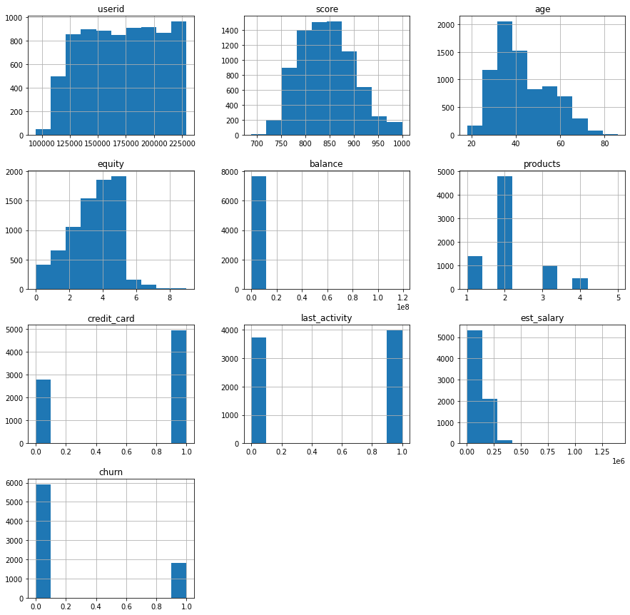

```python
plt.figure()
df_raw[df_raw['balance'].isna()==False].hist(figsize=(15,15))
plt.show()
```

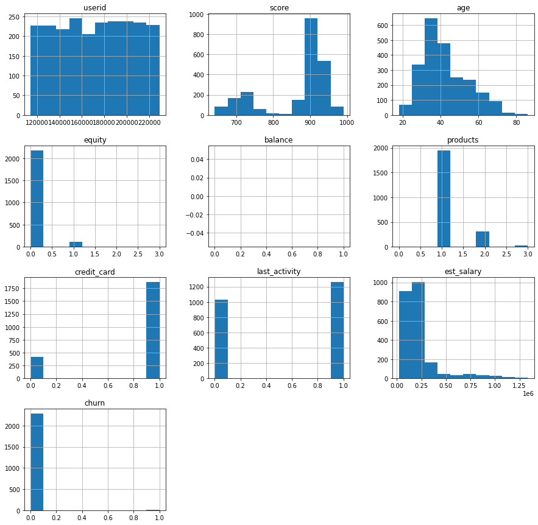

```python
plt.figure()
df_raw[df_raw['balance'].isna()==True].hist(figsize=(15,15))
plt.show()
```

Видим, что клиенты, у которых отсутствуют данные по балансу, - в основном лояльные, доля держателей кредитных карт среди них намного выше, чем аналогичный показатель для тех, у кого имеются данные по балансу, также у таких клиентов в основном отсутствует собственность.  
Кроме того, данные по кредитному рейтингу среди тех, у кого отсутствуют данные по балансу, распределены неравномерно - видим "всплески" по краям и "провал" в середине - у клиентов, у которых нет данных по балансу, кредитный рейтинг либо очень низкий, либо очень высокий.  
Данные по возрасту распределены приблизительно так же, как и у клиентов без пропусков в балансе, в части оценочного дохода - больше доля клиентов с высоким уровнем дохода (но она все равно незначительна на фоне общего количества клиентов).

Вывод: пропуски в данных о балансе могут быть связаны с тем, что не учитывается баланс кредитной карты (и других кредитных продуктов), а кроме этого продукта у клиента ничего нет. Пропуски не заполняем, данные сохраняем.

### Работа с дубликатами

На дубликаты имеет смысл проверять столбец userid, так как в нем должны содержаться уникальные данные.

```python
df_raw.loc[df_raw.duplicated(subset=['userid'],keep=False)==True].sort_values(by='userid')
```

|  | userid | score | city | gender | age | equity | balance | products | credit_card | last_activity | est_salary | churn |
| --- | --- | --- | --- | --- | --- | --- | --- | --- | --- | --- | --- | --- |
| 1893 | 116540 | 883.0 | рыбинск | ж | 55.0 | 1 | 362756.49 | 3 | 0 | 1 | 175920.48 | 1 |
| 7694 | 116540 | 887.0 | ярославль | ж | 38.0 | 0 | NaN | 1 | 0 | 1 | 119247.61 | 0 |
| 7542 | 117943 | 880.0 | ярославль | ж | 40.0 | 0 | NaN | 1 | 1 | 0 | 137718.93 | 0 |
| 4866 | 117943 | 855.0 | рыбинск | ж | 32.0 | 6 | 1036832.93 | 4 | 1 | 1 | 107792.71 | 1 |
| 5896 | 120258 | 905.0 | ярославль | м | 30.0 | 0 | NaN | 1 | 1 | 1 | 146427.96 | 0 |
| ... | ... | ... | ... | ... | ... | ... | ... | ... | ... | ... | ... | ... |
| 2597 | 226719 | 990.0 | ярославль | м | 37.0 | 4 | 14648692.14 | 2 | 0 | 0 | 934412.61 | 1 |
| 8205 | 227795 | 840.0 | рыбинск | м | 34.0 | 2 | 350768.03 | 1 | 1 | 0 | 102036.14 | 1 |
| 8497 | 227795 | 839.0 | ярославль | м | 34.0 | 2 | 326593.14 | 2 | 1 | 0 | 103314.92 | 0 |
| 6457 | 228075 | 839.0 | рыбинск | м | 39.0 | 5 | 507199.85 | 3 | 0 | 1 | 85195.80 | 0 |
| 1247 | 228075 | 932.0 | ярославль | м | NaN | 5 | 7601719.20 | 2 | 1 | 1 | 408121.16 | 0 |

146 rows × 12 columns

Видим, что есть дубликаты в столбце userid, но нет полных дубликатов.

Это может быть связано с особенностью системы присвоения userid, например, сбои в коммуникации между базами при одновременном внесении информации о клиенте в базу в разных городах.

Для того, чтобы решить эту проблему и не потерять данные, необходимо изменить userid у одной из двух записей. В качестве варианта решения - просто прибавим 500000 к userid.

```python
index_zero = 0
userid_zero = 0
for i in df_raw.loc[df_raw.duplicated(subset=['userid'],keep=False)==True].sort_values(by='userid').index:
    if i != index_zero:
        if df_raw.loc[i,'userid']==userid_zero:
            df_raw.loc[i,'userid']=df_raw.loc[i,'userid']+500000
    index_zero = i
    userid_zero = df_raw.loc[i,'userid']
```

```python
df_raw.loc[7694]
```

```
userid              616540
score                887.0
city             ярославль
gender                   ж
age                   38.0
equity                   0
balance                NaN
products                 1
credit_card              0
last_activity            1
est_salary       119247.61
churn                    0
Name: 7694, dtype: object
```

### Кодирование данных

Для того, чтобы выполнить статистический анализ, желательно использовать категориальные переменные, то есть привести данные к такому виду, чтобы признаки кодировались по принципу "есть-нет" (1 или 0).

Для этого для столбцов "city" и "gender" воспользуемся функционалом pandas (при этом не будем создавать столбец для отсутствующих значений, так как из общего анализа данных видно, что в столбцах с указанием пола и города пропуски отсутствуют).

```python
df_copy = df_raw.copy()
df = pd.get_dummies(df_raw, dummy_na=False, columns=['gender', 'city'], dtype='int64')
df['city'] = df_copy['city']
df['gender'] = df_copy['gender']
df=df.rename(columns={'gender_ж':'fem','gender_м':'male','city_ростов':'rostov','city_рыбинск':'rybinsk','city_ярославль':'yaroslavl'})
```

```python
col_names = {'userid':'ID','score':'рейтинг','age':'возраст','equity':'собственность','balance':'баланс','products':'продукты',
             'credit_card':'кредитная карта','last_activity':'активность за прошедший месяц','est_salary':'доход','churn':'отток',
             'fem':'ж','male':'м','rostov':'ростов','rybinsk':'рыбинск','yaroslavl':'ярославль','city':'город','gender':'пол'}
```

```python
df.head()
```

|  | userid | score | age | equity | balance | products | credit_card | last_activity | est_salary | churn | fem | male | rostov | rybinsk | yaroslavl | city | gender |
| --- | --- | --- | --- | --- | --- | --- | --- | --- | --- | --- | --- | --- | --- | --- | --- | --- | --- |
| 0 | 183012 | 850.0 | 25.0 | 1 | 59214.82 | 2 | 0 | 1 | 75719.14 | 1 | 1 | 0 | 0 | 1 | 0 | рыбинск | ж |
| 1 | 146556 | 861.0 | 37.0 | 5 | 850594.33 | 3 | 1 | 0 | 86621.77 | 0 | 1 | 0 | 0 | 1 | 0 | рыбинск | ж |
| 2 | 120722 | 892.0 | 30.0 | 0 | NaN | 1 | 1 | 1 | 107683.34 | 0 | 1 | 0 | 0 | 1 | 0 | рыбинск | ж |
| 3 | 225363 | 866.0 | 51.0 | 5 | 1524746.26 | 2 | 0 | 1 | 174423.53 | 1 | 1 | 0 | 0 | 0 | 1 | ярославль | ж |
| 4 | 157978 | 730.0 | 34.0 | 5 | 174.00 | 1 | 1 | 0 | 67353.16 | 1 | 0 | 1 | 0 | 0 | 1 | ярославль | м |

```python
df.info()
```

```
<class 'pandas.core.frame.DataFrame'>
RangeIndex: 10000 entries, 0 to 9999
Data columns (total 17 columns):
 #   Column         Non-Null Count  Dtype
---  ------         --------------  -----
 0   userid         10000 non-null  int64
 1   score          10000 non-null  float64
 2   age            9974 non-null   float64
 3   equity         10000 non-null  int64
 4   balance        7705 non-null   float64
 5   products       10000 non-null  int64
 6   credit_card    10000 non-null  int64
 7   last_activity  10000 non-null  int64
 8   est_salary     10000 non-null  float64
 9   churn          10000 non-null  int64
 10  fem            10000 non-null  int64
 11  male           10000 non-null  int64
 12  rostov         10000 non-null  int64
 13  rybinsk        10000 non-null  int64
 14  yaroslavl      10000 non-null  int64
 15  city           10000 non-null  object
 16  gender         10000 non-null  object
dtypes: float64(4), int64(11), object(2)
memory usage: 1.3+ MB
```

Данные кодированы, предварительная обработка выполнена.

Дубликаты обработаны.

Пропуски в данных по возрасту решено оставить - они не влияют на общую картину; пропуски в данных по балансу решено оставить - они могут оказать влияние на общую картину.

## ИССЛЕДОВАТЕЛЬСКИЙ АНАЛИЗ ДАННЫХ

к содержанию

### Сравнение портретов типичных клиентов

Для того, чтобы сравнить портреты типичных клиентов, необходимо посмотреть средние и медианные значения признаков.

```python
data_class=classify_data(df)
data_class['equity']='dis'
data_class['products']='dis'
display(data_class)
```

```
{'userid': 'num',
 'score': 'num',
 'age': 'num',
 'equity': 'dis',
 'balance': 'num',
 'products': 'dis',
 'credit_card': 'cat',
 'last_activity': 'cat',
 'est_salary': 'num',
 'churn': 'cat',
 'fem': 'cat',
 'male': 'cat',
 'rostov': 'cat',
 'rybinsk': 'cat',
 'yaroslavl': 'cat',
 'city': 'obj',
 'gender': 'obj'}
```

```python
for col in df.columns:
    if not col in ['churn','userid'] and data_class[col] != 'obj':
        display(col_names[col])
        display('среднее в целом: ' + str(round(df[col].mean(),4)))
        display('медианное в целом: ' + str(round(df[col].median(),4)))
        display('среднее для лояльных/отточных клиентов: ' + str(round(df.loc[df['churn']==0,col].mean(),4)) +
                '/' + str(round(df.loc[df['churn']==1,col].mean(),4)))
        display('медианное для лояльных/отточных клиентов: ' + str(round(df.loc[df['churn']==0,col].median(),4)) +
               '/' + str(round(df.loc[df['churn']==1,col].median(), 4)))
```

```
'рейтинг'
```

```
'среднее в целом: 848.6994'
```

```
'медианное в целом: 853.0'
```

```
'среднее для лояльных/отточных клиентов: 845.4284/863.4011'
```

```
'медианное для лояльных/отточных клиентов: 848.0/866.0'
```

```
'возраст'
```

```
'среднее в целом: 42.7344'
```

```
'медианное в целом: 40.0'
```

```
'среднее для лояльных/отточных клиентов: 43.0208/41.4502'
```

```
'медианное для лояльных/отточных клиентов: 40.0/39.0'
```

```
'собственность'
```

```
'среднее в целом: 2.6276'
```

```
'медианное в целом: 3.0'
```

```
'среднее для лояльных/отточных клиентов: 2.3748/3.7637'
```

```
'медианное для лояльных/отточных клиентов: 3.0/4.0'
```

```
'баланс'
```

```
'среднее в целом: 827794.3065'
```

```
'медианное в целом: 524272.2'
```

```
'среднее для лояльных/отточных клиентов: 733982.5856/1133993.2714'
```

```
'медианное для лояльных/отточных клиентов: 475382.445/782410.47'
```

```
'продукты'
```

```
'среднее в целом: 1.8701'
```

```
'медианное в целом: 2.0'
```

```
'среднее для лояльных/отточных клиентов: 1.7576/2.3758'
```

```
'медианное для лояльных/отточных клиентов: 2.0/2.0'
```

```
'кредитная карта'
```

```
'среднее в целом: 0.6804'
```

```
'медианное в целом: 1.0'
```

```
'среднее для лояльных/отточных клиентов: 0.7092/0.5511'
```

```
'медианное для лояльных/отточных клиентов: 1.0/1.0'
```

```
'активность за прошедший месяц'
```

```
'среднее в целом: 0.5235'
```

```
'медианное в целом: 1.0'
```

```
'среднее для лояльных/отточных клиентов: 0.4837/0.7022'
```

```
'медианное для лояльных/отточных клиентов: 0.0/1.0'
```

```
'доход'
```

```
'среднее в целом: 147866.8855'
```

```
'медианное в целом: 119658.105'
```

```
'среднее для лояльных/отточных клиентов: 147783.2001/148243.0102'
```

```
'медианное для лояльных/отточных клиентов: 118257.715/125390.62'
```

```
'ж'
```

```
'среднее в целом: 0.4995'
```

```
'медианное в целом: 0.0'
```

```
'среднее для лояльных/отточных клиентов: 0.5328/0.35'
```

```
'медианное для лояльных/отточных клиентов: 1.0/0.0'
```

```
'м'
```

```
'среднее в целом: 0.5005'
```

```
'медианное в целом: 1.0'
```

```
'среднее для лояльных/отточных клиентов: 0.4672/0.65'
```

```
'медианное для лояльных/отточных клиентов: 0.0/1.0'
```

```
'ростов'
```

```
'среднее в целом: 0.1417'
```

```
'медианное в целом: 0.0'
```

```
'среднее для лояльных/отточных клиентов: 0.1407/0.1462'
```

```
'медианное для лояльных/отточных клиентов: 0.0/0.0'
```

```
'рыбинск'
```

```
'среднее в целом: 0.2695'
```

```
'медианное в целом: 0.0'
```

```
'среднее для лояльных/отточных клиентов: 0.276/0.2401'
```

```
'медианное для лояльных/отточных клиентов: 0.0/0.0'
```

```
'ярославль'
```

```
'среднее в целом: 0.5888'
```

```
'медианное в целом: 1.0'
```

```
'среднее для лояльных/отточных клиентов: 0.5833/0.6137'
```

```
'медианное для лояльных/отточных клиентов: 1.0/1.0'
```

На основании анализа выше можно составить следующий портрет **лояльного** клиента:

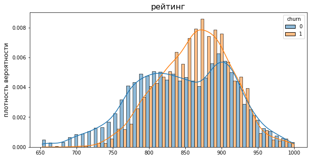

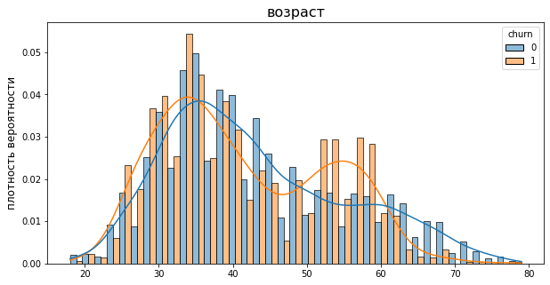

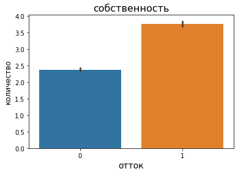

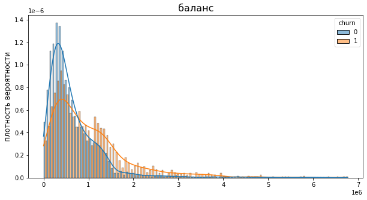

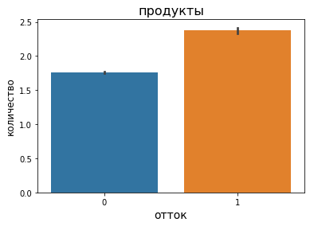

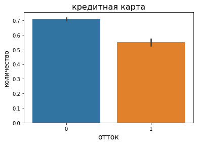

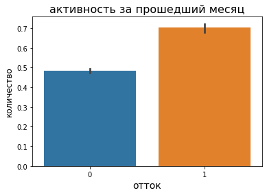

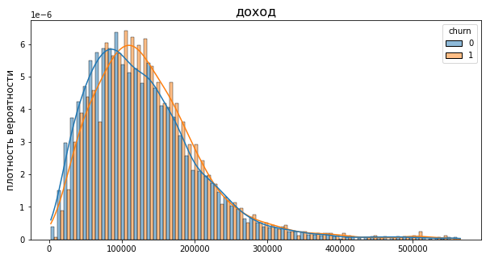

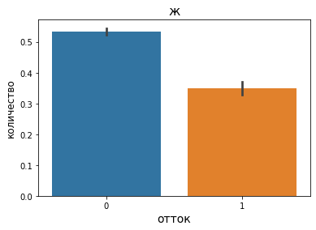

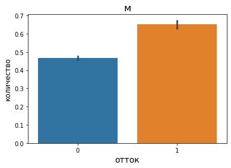

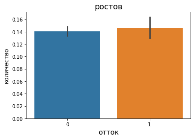

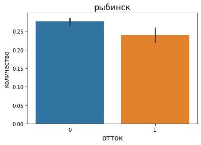

[1 more figures not shown]

```python
for col in df.columns:
    if not col in ['churn','userid']:
        if data_class[col] == 'num':
            z = np.abs(st.zscore(df[col],nan_policy='omit'))
            threshold = 3
            df_outliers = df[z>threshold]
            df_loc=df.drop(df_outliers.index)
            plt.figure(figsize=(10,5))
            sns.histplot(x=col,hue='churn',data=df_loc,common_norm=False,
                         stat='density',
                         multiple='dodge',
                         kde=True)
            plt.title(col_names[col],fontsize=16)
            plt.xlabel('')
            plt.ylabel('плотность вероятности', fontsize=12)
        elif data_class[col]=='cat':
            plt.figure()
            sns.barplot(y=col,x='churn',data=df)
            plt.title(col_names[col],fontsize=16)
            plt.xlabel('отток',fontsize=14)
            plt.ylabel('количество', fontsize=12)
        elif data_class[col]=='dis':
            plt.figure()
            sns.barplot(y=col,x='churn',data=df)
            plt.title(col_names[col],fontsize=16)
            plt.xlabel('отток',fontsize=14)
            plt.ylabel('количество', fontsize=12)
    plt.show()
```

На основании анализа выше можно предварительно составить такой портрет клиента:

- рейтинг лояльного клиента с наибольшей вероятностью находится в пределах 770-840 и 890-920, рейтинг отточного клиента с наибольшей вероятностью находится в пределах 830-900
- возраст лояльного клиента с наибольшей вероятностью находится в пределах 30-45 лет, возраст отточного клиента с наибольшей вероятностью находится в пределах 25-40 лет и 50-60 лет
- в части собственности - в среднем у лояльных клиентов этот показатель меньше, чем у отточных
- баланс лояльных клиентов в среднем меньше, чем у отточных
- количество продуктов у лояльных клиентов составляет с наибольшей вероятностью 1 или 2, у отточных клиентов преобладает 2, но с большей вероятностью - 4
- с большей вероятностью у лояльных клиентов имеется кредитная карта
- с большей вероятностью отточные клиенты за прошедший месяц побывали в банке
- доход лояльных клиентов в среднем меньше, чем у отточных
- женщины показывают большую лояльность, чем мужчины
- значимых различий по городам не наблюдается.

### Распределение непрерывных по разрезам

```python
data_class
```

```
{'userid': 'num',
 'score': 'num',
 'age': 'num',
 'equity': 'dis',
 'balance': 'num',
 'products': 'dis',
 'credit_card': 'cat',
 'last_activity': 'cat',
 'est_salary': 'num',
 'churn': 'cat',
 'fem': 'cat',
 'male': 'cat',
 'rostov': 'cat',
 'rybinsk': 'cat',
 'yaroslavl': 'cat',
 'city': 'obj',
 'gender': 'obj'}
```

Здесь рассмотрим, каким образом непрерывные переменные распределяются по категориям.

К непрерывным переменным относятся:

- рейтинг
- возраст
- недвижимость
- баланс
- количество продуктов
- оценочный доход

Категории включают:

- наличие кредитной карты
- посещение банка за последний месяц
- отток
- пол
- город

Создадим возрастные группы

```python
(df['age']//10*10).value_counts().sort_index().to_frame().reset_index()
```

|  | index | age |
| --- | --- | --- |
| 0 | 10.0 | 29 |
| 1 | 20.0 | 1119 |
| 2 | 30.0 | 3624 |
| 3 | 40.0 | 2401 |
| 4 | 50.0 | 1600 |
| 5 | 60.0 | 992 |
| 6 | 70.0 | 189 |
| 7 | 80.0 | 20 |

```python
age_groups = (df['age']//10*10).value_counts().sort_index().to_frame().reset_index().iloc[[0,2,3,4,5],0].reset_index(drop=True)
age_groups[5]=100
age_groups
```

```
0     10.0
1     30.0
2     40.0
3     50.0
4     60.0
5    100.0
Name: index, dtype: float64
```

```python
df_age_group = df
df_age_group['age_group']=df_age_group['age']//10*10
data_class['age_group']='obj'
```

```python
#for col in df_age_group.columns:
#    if col not in ['age','churn','userid']:
#        if data_class[col]=='num':
#            sns.heatmap(df_age_group.groupby([pd.cut(df['age'],age_groups),
#                                    pd.cut(df[col],
#                                           (df[col].quantile([0,0.25,0.5,0.75,0.95,1]).reset_index()[col].unique()))],
#                                   observed=False).churn.mean().unstack(),annot=True,vmin=0,vmax=1,
#                       cmap='Reds')
#            plt.title('Доля оттока в разрезе: ' + col_names['age'] + ' и ' + col_names[col], fontsize=18)
#            plt.ylabel(col_names['age'],fontsize=14)
#            plt.xlabel(col_names[col],fontsize=14)
#            plt.xticks(rotation=45)
#        plt.show()
```

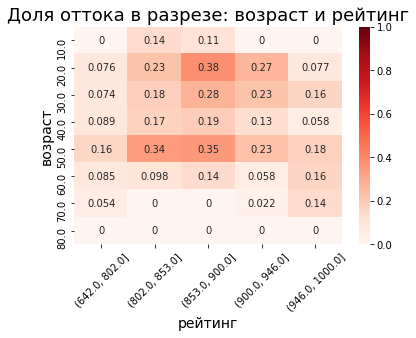

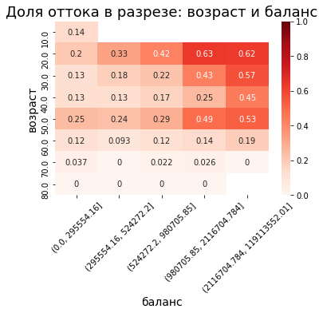

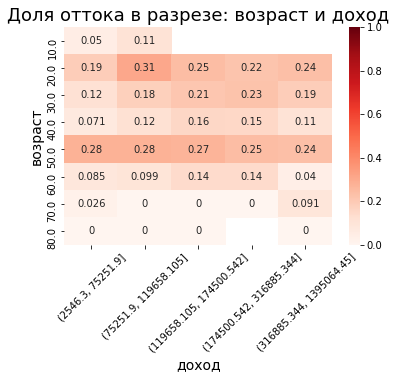

```python
for col in df_age_group.columns:
    if col not in ['age','churn','userid']:
        if data_class[col]=='num':
            sns.heatmap(df_age_group.groupby(['age_group',pd.cut(df[col],
                                           (df[col].quantile([0,0.25,0.5,0.75,0.95,1]).reset_index()[col].unique()))],
                                   observed=False).churn.mean().unstack(),annot=True,vmin=0,vmax=1,
                       cmap='Reds')
            plt.title('Доля оттока в разрезе: ' + col_names['age'] + ' и ' + col_names[col], fontsize=18)
            plt.ylabel(col_names['age'],fontsize=14)
            plt.xlabel(col_names[col],fontsize=14)
            plt.xticks(rotation=45)
        plt.show()
```

Видим, что доля оттока среди относительно молодых людей с высоким балансом значительно выше, чем среди прочих.

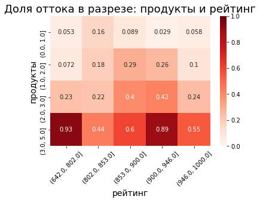

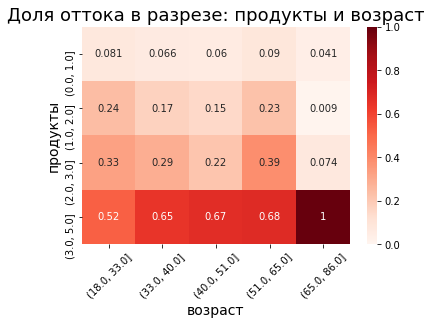

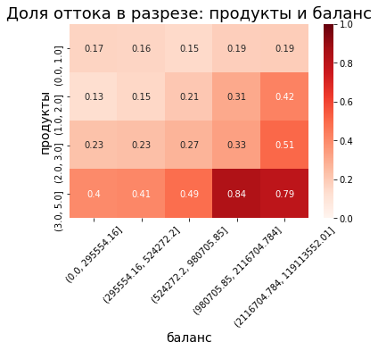

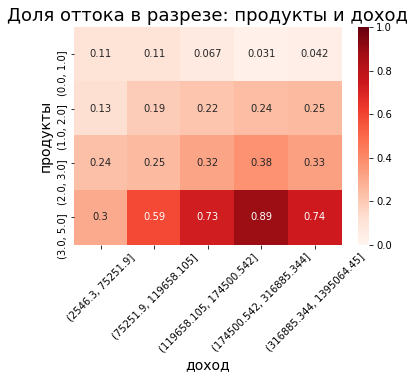

```python
for col in df.columns:
    if col not in ['products','churn','userid']:
        if data_class[col]=='num':
            sns.heatmap(df.groupby([pd.cut(df['products'],df['products'].quantile([0,0.25,0.5,0.75,0.95,1]).reset_index()['products'].unique()),
                                    pd.cut(df[col],
                                           (df[col].quantile([0,0.25,0.5,0.75,0.95,1]).reset_index()[col].unique()))],
                                   observed=False).churn.mean().unstack(),annot=True,vmin=0,vmax=1,
                       cmap='Reds')
            plt.title('Доля оттока в разрезе: ' + col_names['products'] + ' и ' + col_names[col], fontsize=18)
            plt.ylabel(col_names['products'],fontsize=14)
            plt.xlabel(col_names[col],fontsize=14)
            plt.xticks(rotation=45)
        plt.show()
```

Видим, что доля оттока высока среди клиентов с количеством продуктов более 3.

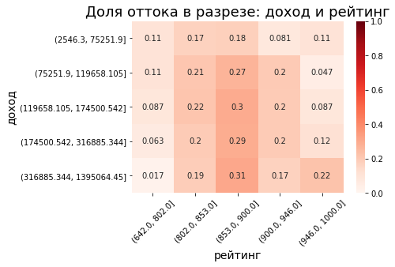

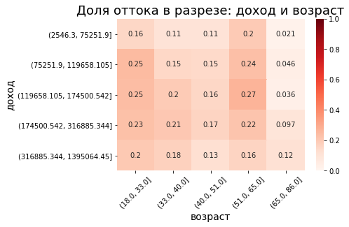

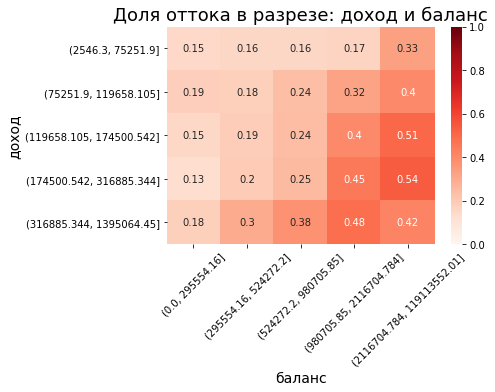

```python
for col in df.columns:
    if col not in ['est_salary','churn','userid']:
        if data_class[col]=='num':
            sns.heatmap(df.groupby([pd.cut(df['est_salary'],df['est_salary'].quantile([0,0.25,0.5,0.75,0.95,1]).reset_index()['est_salary'].unique()),
                                    pd.cut(df[col],
                                           (df[col].quantile([0,0.25,0.5,0.75,0.95,1]).reset_index()[col].unique()))],
                                   observed=False).churn.mean().unstack(),annot=True,vmin=0,vmax=1,
                       cmap='Reds')
            plt.title('Доля оттока в разрезе: ' + col_names['est_salary'] + ' и ' + col_names[col], fontsize=18)
            plt.ylabel(col_names['est_salary'],fontsize=14)
            plt.xlabel(col_names[col],fontsize=14)
            plt.xticks(rotation=45)
        plt.show()
```

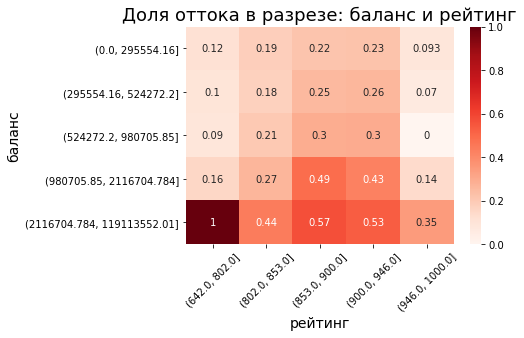

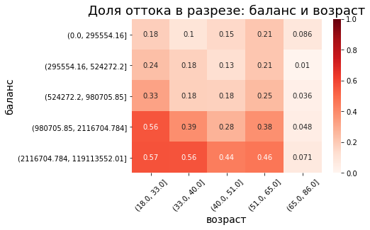

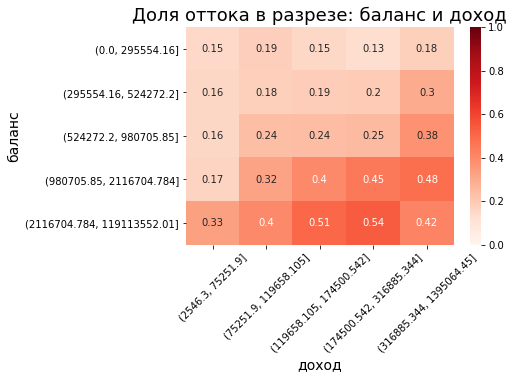

```python
for col in df.columns:
    if col not in ['balance','churn','userid']:
        if data_class[col]=='num':
            sns.heatmap(df.groupby([pd.cut(df['balance'],df['balance'].quantile([0,0.25,0.5,0.75,0.95,1]).reset_index()['balance'].unique()),
                                    pd.cut(df[col],
                                           (df[col].quantile([0,0.25,0.5,0.75,0.95,1]).reset_index()[col].unique()))],
                                   observed=False).churn.mean().unstack(),annot=True,vmin=0,vmax=1,
                       cmap='Reds')
            plt.title('Доля оттока в разрезе: ' + col_names['balance'] + ' и ' + col_names[col], fontsize=18)
            plt.ylabel(col_names['balance'],fontsize=14)
            plt.xlabel(col_names[col],fontsize=14)
            plt.xticks(rotation=45)
        plt.show()
```

### Корреляционный анализ

Рассмотрим корреляции в данных.

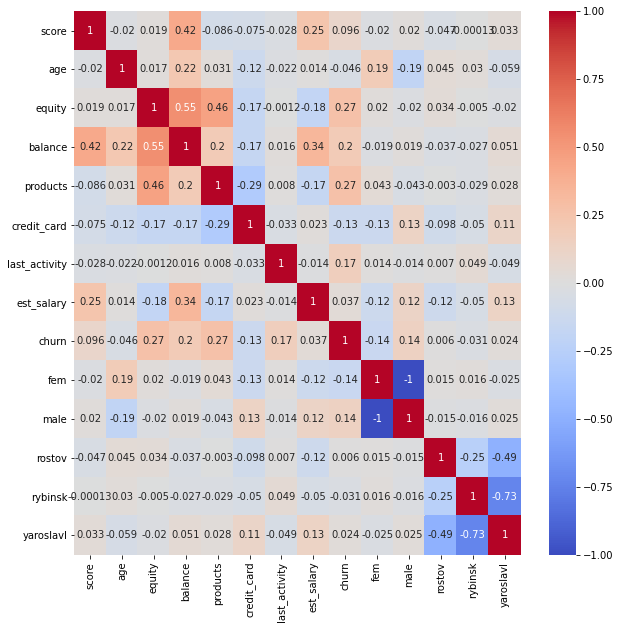

```python
corr=df.iloc[:,1:-2].corr(method='spearman')
plt.figure(figsize=(10,10))
sns.heatmap(corr,cmap='coolwarm',annot=True)
plt.show()
```

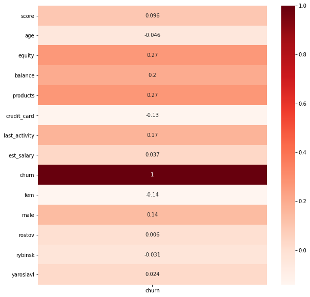

```python
corr=df.iloc[:,1:-2].corr(method='spearman')
blue = sns.diverging_palette(225, 10, as_cmap=True)
plt.figure(figsize=(10,10))
sns.heatmap(corr[['churn']],cmap='Reds',annot=True)
plt.show()
```

На основании корреляционного анализа видим слабую прямую зависимость от баллов собственности, суммы баланса и количества продуктов, также видим слабую прямую зависимость от посещения банка за последний месяц; слабую обратную зависимость от наличия кредитной карты; имеется некоторая зависимость от пола - мужчины более склонны к оттоку, чем женщины. По остальным параметрам видим очень слабую зависимость.

### Предварительные формулировки статистических гипотез

1. Возраст клиентов, которые пользуются одним продуктом банка, статистически не отличается от возраста клиентов, которые пользуются двумя продуктами банка.
2. Уход клиента не зависит от дохода клиента.
3. Количество продуктов, которыми пользуется клиент, влияет на его лояльность.
4. Наличие кредитной карты влияет на лояльность клиентов.

## ПРОВЕРКА СТАТИСТИЧЕСКИХ ГИПОТЕЗ

к содержанию

Предварительно сформулированы 4 гипотезы. Ниже мы формулируем для них нулевые и альтернативные гипотезы, выбираем и обосновываем методы, которыми будем эти гипотезы проверять.

### Гипотеза 1.

**Нулевая гипотеза**: средний возраст клиентов, которые пользуются одним продуктом банка, статистически не отличается от среднего возраста клиентов, которые пользуются двумя продуктами банка.

**Альтернативная гипотеза**: средний возраст клиентов, которые пользуются одним продуктом банка, статистически отличается от среднего возраста клиентов, которые пользуются двумя продуктами банка.

```python
df['products'].value_counts()
```

```
2    5126
1    3341
3    1039
4     474
5      19
0       1
Name: products, dtype: int64
```

Согласно Центральной предельной теореме, выборочное среднее распределяется близко к нормальному при достаточно большом размере выборки.  
В нашем случае будем сравнивать выборочные средние для двух больших совокупностей, поэтому будем использовать ttest, который подходит для решения такой задачи. При этом укажем, что дисперсии могут быть различными, так как выборки хоть и большие, но не равные по размеру.

Уровень статистической значимости задаем стандартный - 0.05.

```python
alpha = 0.05
one_prod = df.loc[df['products']==1, 'age']
two_prod = df.loc[df['products']==2, 'age']
results = st.ttest_ind(one_prod, two_prod, alternative='two-sided',equal_var=False,nan_policy='omit')

print('p-значение:', results.pvalue)

if results.pvalue < alpha:
    print('Отвергаем нулевую гипотезу')
else:
    print('Не получилось отвергнуть нулевую гипотезу')
```

```
p-значение: 0.03299080704232691
Отвергаем нулевую гипотезу
```

Возраст клиентов, пользующихся двумя продуктами банка, статистически значимо отличается от возраста клиентов, пользующихся одним продуктом банка. Нулевая гипотеза отвергнута.

### Гипотеза 2.

**Нулевая гипотеза**: средний доход лояльных клиентов банка статистически не отличается от среднего дохода отточных клиентов.

**Альтернативная гипотеза**: средний доход лояльных клиентов банка статистически отличается от среднего дохода отточных клиентов.

Аналогично пункту выше, по тем же причинам, будем использовать ttest с аналогичными параметрами: отличающаяся дисперсия, уровень статистической значимости - 0.05.

```python
alpha = 0.05
loyal = df.loc[df['churn']==0, 'est_salary']
churn = df.loc[df['churn']==1, 'est_salary']
results = st.ttest_ind(loyal, churn, alternative='two-sided',equal_var=False,nan_policy='omit')

print('p-значение:', results.pvalue)

if results.pvalue < alpha:
    print('Отвергаем нулевую гипотезу')
else:
    print('Не получилось отвергнуть нулевую гипотезу')
```

```
p-значение: 0.8887054822123845
Не получилось отвергнуть нулевую гипотезу
```

Средний доход лояльных клиентов статистически не отличается от среднего дохода отточных клиентов.

### Гипотеза 3.

**Нулевая гипотеза**: количество продуктов, которыми пользуются лояльные клиенты банка, статистически не отличается от количества продуктов, которыми пользуются отточные клиенты.

**Альтернативная гипотеза**: количество продуктов, которыми пользуются лояльные клиенты банка, статистически отличается от количества продуктов, которыми пользуются отточные клиенты.

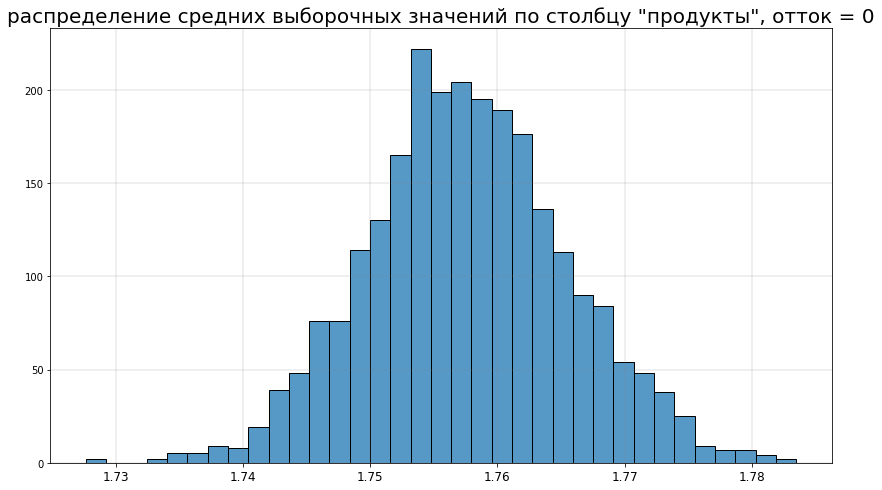

```
'средние выборочные в наборе данных при оттоке = 0 распределены нормально'
```

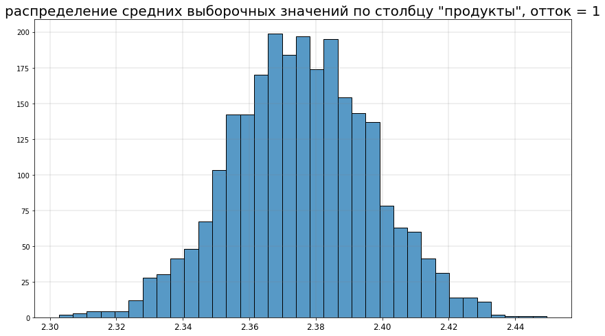

```
'средние выборочные в наборе данных при оттоке = 1 распределены нормально'
```

```python
for i in (0,1):
    smp_mean = [df.loc[df['churn']==i,'products'].sample(frac=1, replace=True).mean() for _ in range(int(len(df)*0.25))]
    plt.figure(figsize=(14,8))
    plt.title('распределение средних выборочных значений по столбцу "продукты", отток = ' + str(i),fontsize=20)
    sns.histplot(smp_mean,bins=35)
    plt.grid(color='grey', lw=0.25)
    plt.ylabel('')
    plt.xticks(fontsize=12)
    plt.show()
    k2, p = st.normaltest(smp_mean)
    if p>0.05:
        display('средние выборочные в наборе данных при оттоке = ' + str(i) + ' распределены нормально')
    else:
        display('средние выборочные в наборе данных при оттоке = ' + str(i) + ' распределены не нормально')
```

Для проверки этой гипотезы также можем использовать ttest для независимых выборок, так как средние выборочные распределены нормально.

Уровень статистической значимости задаем стандартный - 0.05.

```python
alpha = 0.05
loyal = df.loc[df['churn']==0, 'products']
churn = df.loc[df['churn']==1, 'products']
results = st.ttest_ind(loyal, churn, alternative='two-sided',equal_var=False,nan_policy='omit')

print('p-значение:', results.pvalue)

if results.pvalue < alpha:
    print('Отвергаем нулевую гипотезу')
else:
    print('Не получилось отвергнуть нулевую гипотезу')
```

```
p-значение: 1.9356112628058777e-138
Отвергаем нулевую гипотезу
```

Количество продуктов, которыми пользуются лояльные клиенты банка, статистически отличается от количества продуктов, которыми пользуются отточные клиенты.

### Гипотеза 4.

**Нулевая гипотеза**: среднее количество лояльных клиентов с кредитными картами статистически не отличается от среднего количества отточных клиентов с кредитными картами.

**Альтернативная гипотеза**: среднее количество лояльных клиентов с кредитными картами статистически отличается от среднего количества отточных клиентов с кредитными картами.

Поскольку данные бинарные (0 и 1), то для проверки этой гипотезы будем использовать ztest для проверки долей.

Уровень статистической значимости задаем стандартный - 0.05.

```python
alpha = 0.05
loyal = df.loc[df['churn']==0, 'credit_card']
churn = df.loc[df['churn']==1, 'credit_card']
count = np.array([
    len(loyal[loyal == 1]),
    len(churn[churn == 1])
])
nobs = np.array([len(loyal), len(churn)])
z_stat, p_value = proportions_ztest(count, nobs)

print('p-значение:', p_value)

if p_value < alpha:
    print('Отвергаем нулевую гипотезу')
else:
    print('Не получилось отвергнуть нулевую гипотезу')
```

```
p-значение: 4.3391063308323515e-39
Отвергаем нулевую гипотезу
```

Среднее количество лояльных клиентов с кредитными картами статистически отличается от среднего количества отточных клиентов с кредитными картами.

## СПЕЦИАЛЬНЫЙ АНАЛИЗ ДАННЫХ

к содержанию

Здесь описаны 3 основных сегмента клиентов банка, на которые необходимо обратить внимание для снижения уровня оттока клиентов.

Сегменты составляются на основании параметров, которые связаны с отточностью:

1. Количество продуктов
2. Возраст и пол
3. Баланс
4. Наличие или отсутствие кредитной карты

```python
columns_study=['products','balance','age','est_salary','last_activity', 'credit_card']
```

Таким образом, наиболее важными сегментами представляются следующие:

### Сегмент 1

Клиент - имеет количество продуктов больше 3, пол не важен, возраст - 18-40 лет.

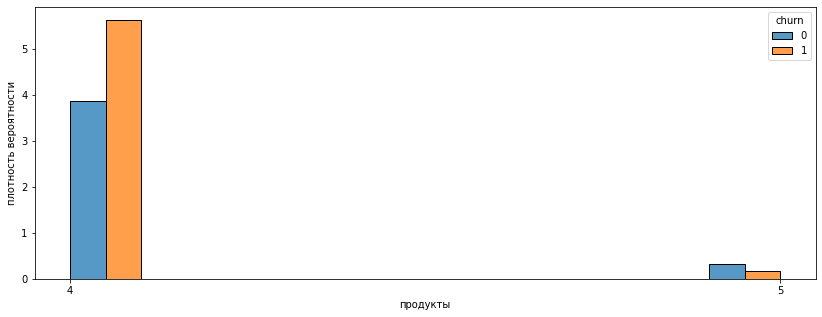

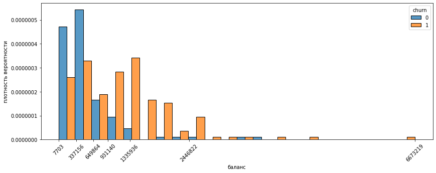

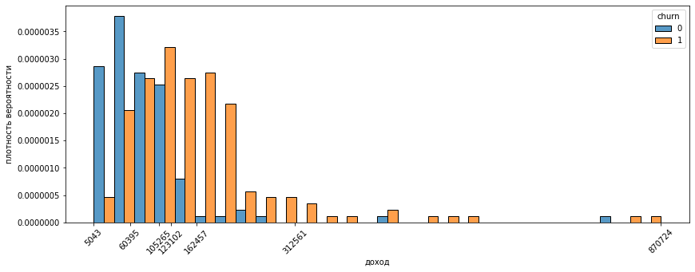

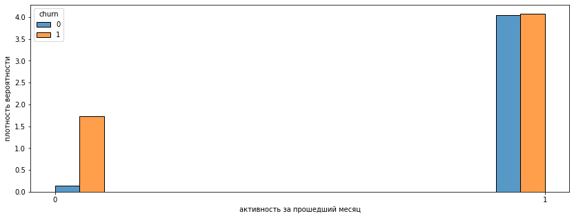

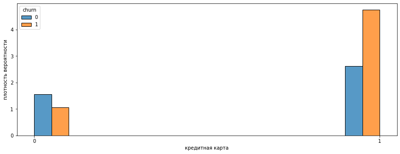

```python
for col in columns_study:
        if col not in ['userid','age','churn','city','gender']:
            plt.figure(figsize=(14,5))
            if col=='balance':
                z = np.abs(st.zscore(df[col],nan_policy='omit'))
                threshold = 3
                df_outliers = df[z>threshold]
                df_loc=df.drop(df_outliers.index)
            else:
                df_loc=df
            data_seg = df_loc.loc[(df_loc['age']>=18)&(df_loc['age']<40) & (df_loc['products'] >3)]
            sns.histplot(data=data_seg,x=col,hue='churn',stat='density',multiple='dodge')
            plt.ticklabel_format(style='plain')
            if data_class[col]=='cat':
                plt.xticks([0,1])
            elif data_class[col]=='num':
                plt.xticks(pd.Series(data_seg[col].quantile([0,0.25,0.5,0.6,0.75,0.95,1]).reset_index()[col].unique()),
                           rotation=45)
            elif col=='products':
                plt.xticks(data_seg['products'].unique())
            plt.xlabel(col_names[col])
            plt.ylabel('плотность вероятности')
        plt.show()
```

### Сегмент 2

Клиент - мужчина, возраст - 18-40 лет и 50-60 лет, баланс - более 980 тыс. у.е.

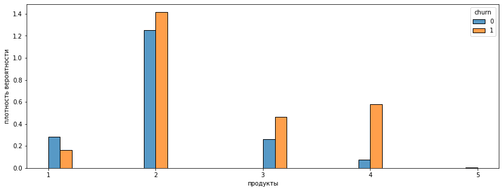

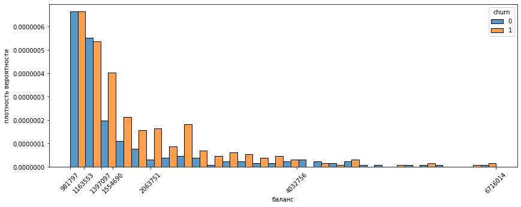

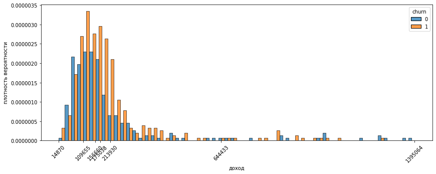

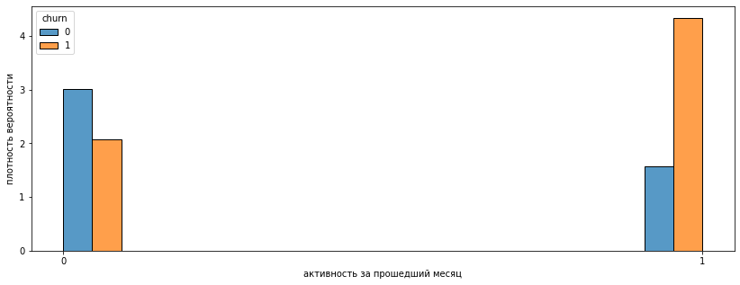

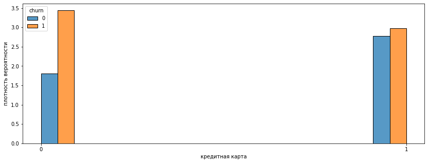

```python
for col in columns_study:
        if col not in ['userid','age','churn','city','gender']:
            plt.figure(figsize=(14,5))
            if col=='balance':
                z = np.abs(st.zscore(df[col],nan_policy='omit'))
                threshold = 3
                df_outliers = df[z>threshold]
                df_loc=df.drop(df_outliers.index)
                df_loc=df_loc.query('age>=18 and age < 40 or age>=50 and age<60')
            else:
                df_loc=df.query('age>=18 and age < 40 or age>=50 and age<60')
            data_seg = df_loc.loc[(df_loc['gender']=='м') & (df_loc['balance'] >980000)]
            sns.histplot(data=data_seg,x=col,hue='churn',stat='density',multiple='dodge')
            plt.ticklabel_format(style='plain')
            if data_class[col]=='cat':
                plt.xticks([0,1])
            elif data_class[col]=='num':
                plt.xticks(pd.Series(data_seg[col].quantile([0,0.25,0.5,0.6,0.75,0.95,1]).reset_index()[col].unique()),
                           rotation=45)
            elif col=='products':
                plt.xticks(data_seg['products'].unique())
            plt.xlabel(col_names[col])
            plt.ylabel('плотность вероятности')
        plt.show()
```

### Сегмент 3

Клиент - мужчина, кредитной карты не имеет, баланс - более 980 тыс. у.е.

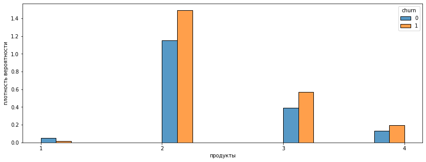

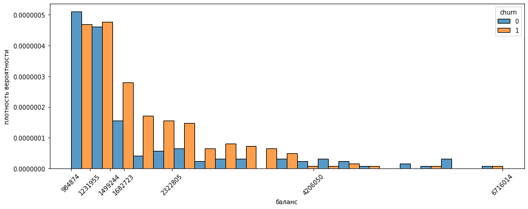

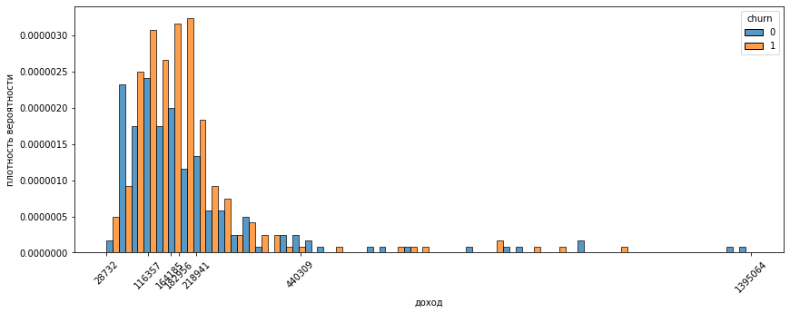

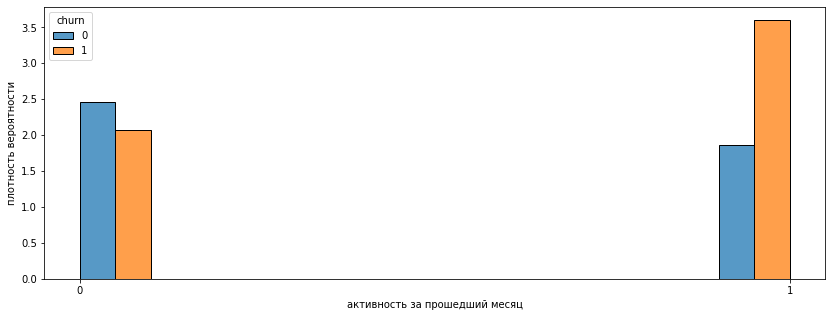

```python
for col in columns_study:
        if col not in ['userid','age','churn','city','gender','credit_card']:
            plt.figure(figsize=(14,5))
            if col=='balance':
                z = np.abs(st.zscore(df[col],nan_policy='omit'))
                threshold = 3
                df_outliers = df[z>threshold]
                df_loc=df.drop(df_outliers.index)
            else:
                df_loc=df
            data_seg = df_loc.loc[(df_loc['gender']=='м') & (df_loc['balance'] >980000) & (df_loc['credit_card']==0)]
            sns.histplot(data=data_seg,x=col,hue='churn',stat='density',multiple='dodge')
            plt.ticklabel_format(style='plain')
            if data_class[col]=='cat':
                plt.xticks([0,1])
            elif data_class[col]=='num':
                plt.xticks(pd.Series(data_seg[col].quantile([0,0.25,0.5,0.6,0.75,0.95,1]).reset_index()[col].unique()),
                           rotation=45)
            elif col=='products':
                plt.xticks(data_seg['products'].unique())
            plt.xlabel(col_names[col])
            plt.ylabel('плотность вероятности')
        plt.show()
```

## ЗАКЛЮЧЕНИЕ

к содержанию

Похоже, одним из главных признаков, по которым можно определить, будет ли клиент уходить, является количество продуктов. Второй признак - баланс, но он вторичен по отношению к количеству продуктов - при большом балансе и небольшом количестве продуктов клиент скорее останется лояльным. Третий признак - кредитная карта. Кредитная карта скорее признак лояльного клиента. Кроме того, мужчины с большей вероятностью становятся отточными клиентами.

Если клиент в последний месяц был в банке - возможно, он станет отточным; на это тоже надо обращать внимание. Судя по всему, чем реже клиент посещает банк, тем лучше для банка с точки зрения удержания клиента.

### Рекомендации

Необходимо пересмотреть портфель продуктов:  
Во-первых, если у клиента более 3 продуктов и клиенту не больше 40 лет, он с высокой долей вероятности уходит. Это может быть связано, например, с неудобным мобильным клиентом, которым пользуются люди в этом возрасте. Также это может быть связано с наличием или отсутствием кредитных продуктов, кроме кредитной карты - ее наличие или отсутствие в данном сегменте слабо влияет на вероятность ухода клиента.  
Во-вторых, необходимы продукты, интересные для мужчин в возрасте 18-40 и 50-60 лет с высоким балансом - например, продукты для инвестиционной деятельности, или выгодные вклады. Мотивы ухода без детального изучения используемых клиентами продуктов непонятны.  
В-третьих, необходимо обратить внимание на мужчин с высоким балансом и без кредитной карты, - возможно, следует пересмотреть условия предоставления кредитной карты, так как наличие у клиента кредитной карты повышает лояльность.

Кроме того, следует изучить портфели продуктов конкурентов.  
Помимо собственно портфеля продуктов важно удобство взаимодействия с банком, в частности - интернет-банкинг и мобильное приложение; учитывая, что отточными клиентами часто являются относительно молодые люди, можно предположить, что дело в удобстве взаимодействия с банком. Рекомендуется *дополнительное исследование*.

### Презентация

Ссылка на презентацию тут.